# act_report

## WeRateDogs Twitter Insights & Analysis

### Introduction

This project wrangles, analyzes, and visualizes the tweet archive of Twitter user @dog_rates, otherwise known as WeRateDogs. WeRateDogs is a Twitter account that rates people's dogs with a humorous comment about the dog. This analysis focuses on the distribution of ratings and the relationship between rating, retweets, and favorites.

### Gathering Data

Data was obtained from three sources:

• WeRateDogs twitter archive  
• Udacity's Twitter image prediction file  
• Twitter API

### Assessing Data

Data was assessed visually and programmatically in python using a Jupyter notebook utilizing the following python libraries:

• Pandas  
• Numpy  
• Tweepy  
• Requests  
• Json  
• Matplotlib  
• Seaborn  
• Io  
• Urllib  
• PIL

This analysis focuses on only original tweets with images that were retweeted on or before August 1 2017. Any data failing to meet this criteria is not included in this analysis.

### Cleaning Data

Before cleaning the data, all data was copied to new dataframes. Quality and tidiness issues were documented utilizing the Define-Code-Test framework. Once cleaned, all data was merged into a master dataframe and saved to csv.

### Storing Data

The gathered, cleaned, and assessed master dataframe was saved to the twitter_archive_master.csv file.

### Analysis & Visualization

> 81.7% of dogs that were retweeted had ratings between 8 and 12

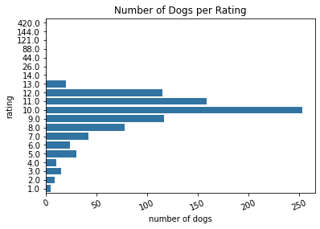

I created three ratings groups to make condense the ratings:

> • Low: Ratings below 8  
> • High: Ratings between 8 and 12  
> • Highest: Ratings above 12

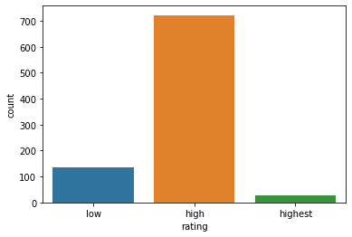

> All dogs have more favorites than retweets:

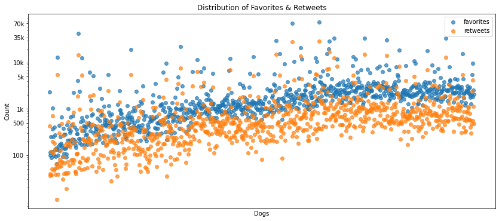

> There is a strong positive correlation between retweets and favorites:

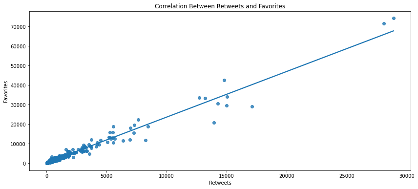

> The dog with the most favorites and the most retweets is:

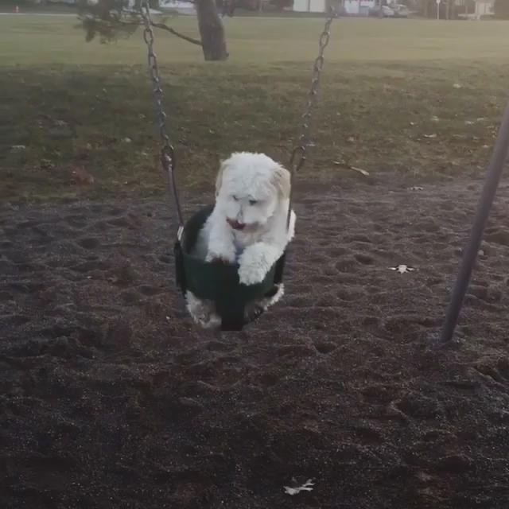